# Deep Dive #4

## Intro

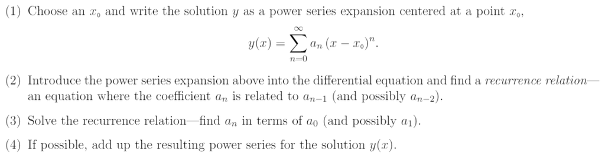

## Question 1

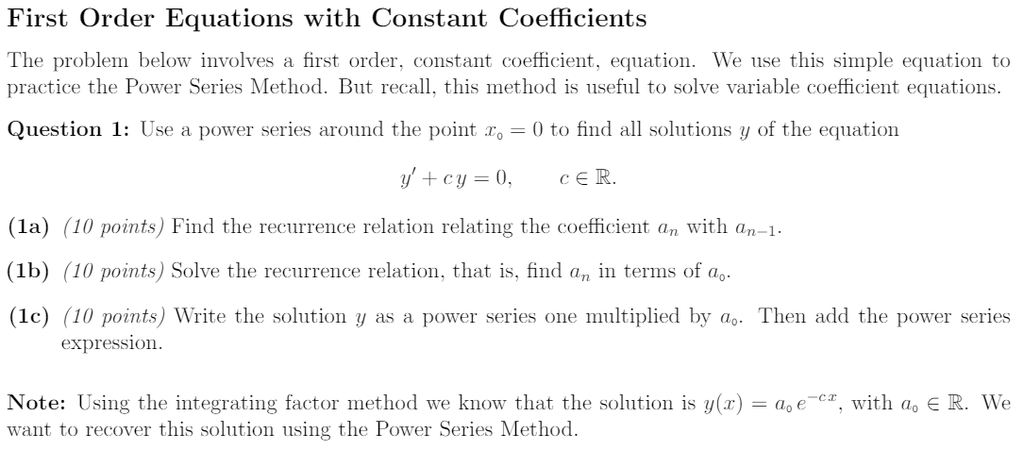

With $x_0=0$ the power series expansion is

$$y(x)=\sum_{n=0}^\infty a_nx^n \\ y'(x)=\sum_{n=0}^\infty na_nx^{(n-1)} $$

(1a) Using the relationship between $y$ and $y'$ we get $$ y' + cy = 0 \\ c\sum_{n=0}^\infty a_nx^n=c\sum_{n=1}^\infty a_{n-1}x^{n-1} \\ %=c\sum_{n=0}^\infty a_{n-1}x^{n-1} -ca_{(-1)} \sum_{n=0}^\infty na_nx^{n-1}=\sum_{n=1}^\infty na_nx^{n-1} \\ 0=\sum_{n=0}^\infty na_nx^{n-1} + c\sum_{n=0}^\infty a_nx^n \\ 0=\sum_{n=1}^\infty na_nx^{n-1}+c\sum_{n=1}^\infty a_{n-1}x^{n-1} \\ 0=\sum_{n=1}^\infty(na_n+ca_{n-1})x^{n-1} $$ Since each $x^{n-1}$ doesn't interact, each coefficient must also equal zero

(1b) Using the above formula, we'll derive any $a_n$ in terms of $a_0$. Ideally we'd do a proof by induction but this'll do for me $$ a_1=-ca_0 \\ a_2 = -\frac{c}{2}a_{1}=\frac{c^2}{2}a_0 \\ a_3= -\frac{c}{3}a_2=-\frac{c^3}{6}a_0 \\ a_n = (-1)^n\frac{c^{n}}{n!}a_0 $$

(1c) $$y(x)=\sum_{n=0}^\infty(-1)^n\frac{c^{n}}{n!}a_0x^n=a_0\sum_{n=0}^\infty\frac{(-cx)^{n}}{n!} \\ y(x)=a_0e^{-cx} $$

## Question 2

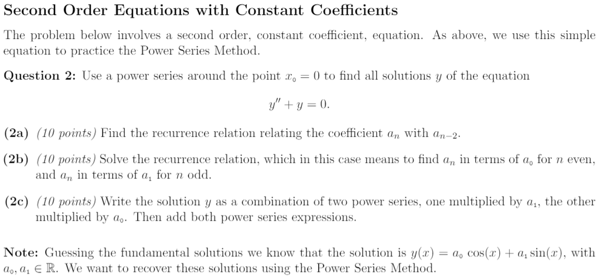

(2a) $$ y'\left( x \right) = \sum\limits_{n = 1}^\infty {n{a_n}{x^{n - 1}}} \hspace{0.25in}y''\left( x \right) = \sum\limits_{n = 2}^\infty {n\left( {n - 1} \right){a_n}{x^{n - 2}}} \\ 0=\sum\limits_{n = 2}^\infty {n\left( {n - 1} \right){a_n}{x^{n - 2}}} + \sum\limits_{n = 0}^\infty {{a_n}{x^n}} \\ $$ We'll shift down to get the same $x^n$ powers $$ \sum\limits_{n = 0}^\infty {\left( {n + 2} \right)\left( {n + 1} \right){a_{n + 2}}{x^n}} + \sum\limits_{n = 0}^\infty {{a_n}{x^n}} = 0 \\ \sum\limits_{n = 0}^\infty {( {\left( {n + 2} \right)\left( {n + 1} \right){a_{n + 2}} + {a_n}} ){x^n}} = 0 $$ Again, each coefficient of the power must also be zero $$(n+2)(n+1)a_{n+2}+a_n=0 \\ a_{n+2}=-\frac{a_n}{(n+2)(n+1)} \\ a_n=-\frac{1}{n(n-1)}a_{n-2} $$

(2b) We'll work through it using the same methods

$$ {a_2} = \frac{{ - {a_0}}}{{\left( 2 \right)\left( 1 \right)}} \\ a_4 = \frac{{{a_0}}}{{\left( 4 \right)\left( 3 \right)\left( 2 \right)\left( 1 \right)}} \\ a_{2n} = \frac{(-1)^na_0}{(2n)!}\\ {a_3} = \frac{{ - {a_1}}}{{\left( 3 \right)\left( 2 \right)}} \\ {a_5} = \frac{{{a_1}}}{{\left( 5 \right)\left( 4 \right)\left( 3 \right)\left( 2 \right)}} \\ a_{2n+1}=\frac{(-1)^na_1}{{(2n+1)}!} $$

(2c) We need $a_0$ and $a_1$ before we can get to the $a_n$ stuff

$$y(x)=\sum_{n =0}^\infty a_nx^n=a_0+a_1x+\sum_{n = 2}^\infty \frac{(-1)^na_0}{(2n)!}x^{2n} + \frac{(-1)^na_1}{{(2n+1)}!}x^{2n+1} \\ = a_0\sum_{n = 0}^\infty \frac{(-1)^n}{(2n)!}x^n+a_1\sum_{n = 0}^\infty \frac{(-1)^n}{{(2n+1)}!}x^n \\ = a_0\cos(x)+a_1\sin(x)$$

## Question 3

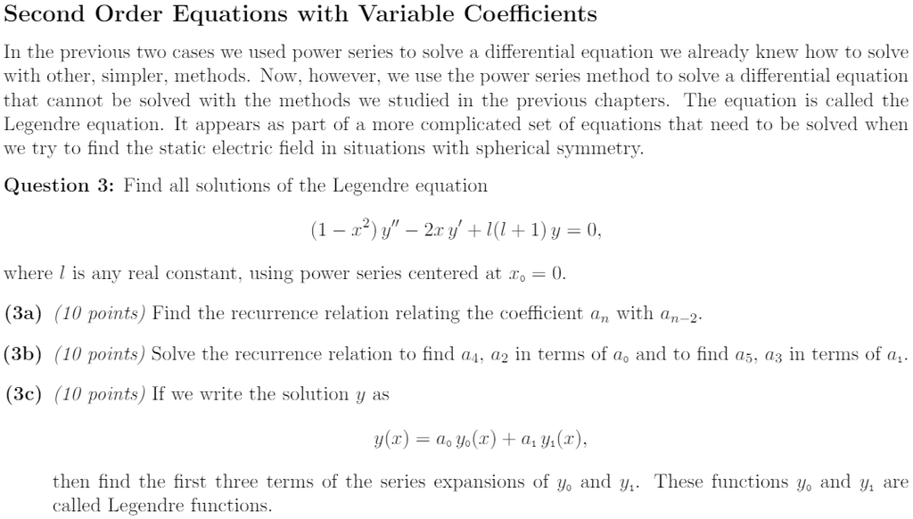

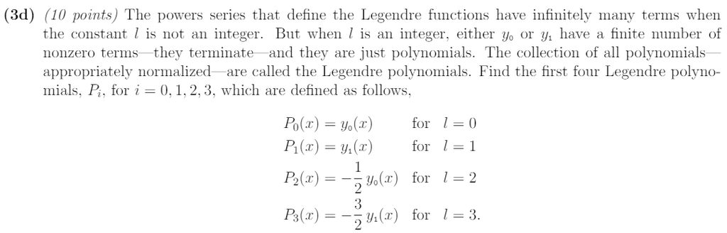

Hey I know this one from E&M

(3a) Multiply the power series for $y'$ and $y''$ by their variable coefficients

(3d)

Have a great day!